# Supermarket_Store_Analytics

totogot

The perceived task at hand assumes a large supermarket chain in the UK (Tesco) is interesting in acquiring a competitor chain, following which the challenge is to identify reasonable geographic regions into which to segment he stores, and most appropriate locations to position warehouse depots for stocking the stores.

The approach taken makes use of clustering techniques, as well as third part applications (run on Docker) to arrive at a solution.

The intention is to provide an example of how to work with geospatial data, in a way that could be applicable to a range of different industries - from logistics to marketing - and sectors - from retail to healthcare.

##Install Packages

```r
#install.packages("leaflet")
#install.packages("tidyverse")
#install.packages("leaflet")
#install.packages("httr")
#install.packages("writexl")
#install.packages("readxl")
#install.packages("leaflet")
#install.packages("geosphere")
#install.packages("sf")
#install.packages("cluster")
#install.packages("factoextra")
#install.packages("dendextend")
#install.packages("dbscan")
#install.packages("curl")

library(httr)
library(readxl)
library(ggplot2)
library(tidyverse)
library(leaflet)
library(htmltools)
library(geosphere)
library(sf)
library(cluster)
library(factoextra)
library(dendextend)
library(dbscan)
library(curl)
```

## Define Functions

```r
# add leaflet title
overlayTitle <- function(plot, text) {

  tag.map.title <- tags$style(HTML("
  .leaflet-control.map-title {
    transform: translate(-50%,20%);
    position: fixed !important;
    left: 50%;
    text-align: center;
    padding-left: 10px;
    padding-right: 10px;
    background: rgba(255,255,255,0.75);
    font-weight: regular;
    font-size: 18px;
  }
  "))

  title <- tags$div(
    tag.map.title, HTML(text)
  )
  plot %>% addControl(title, position = "topleft", className = "map-title")

}


# compute distance from two coords
calcHaversine <- function(loc1, loc2) {

  df <- matrix(c(loc1[1], loc2[1], loc1[2], loc2[2]), nrow = 2)
  dist <- distHaversine(df)
  return(dist)
}


# compute the number of locations within 500m
calcCloseStore <- function(master_stores, target_stores) {

  # convert both tables to sf standard
  master_stores_sf <- st_as_sf(master_stores, coords=c('lng', 'lat'), crs="epsg:4326")
  target_stores_sf <- st_as_sf(target_stores, coords=c('lng', 'lat'), crs="epsg:4326")

  # compute distance matrix
  # each row represents a target location and columns their distance to a master store (in meters)
  dist = st_distance(target_stores_sf, master_stores_sf)

  # convert to dataframe and compute the row min (we only care if it is within 500m not how often)
  dist <- data.frame(dist)
  dist$min <- apply(dist[], MARGIN =  1, FUN = min)

  # compute number of stores within 500m of a master brand store
  dist_close <- dist %>%
    filter(min <=500)

  close_stores <- nrow(dist_close)

  return(close_stores)
}
```

## Main Run

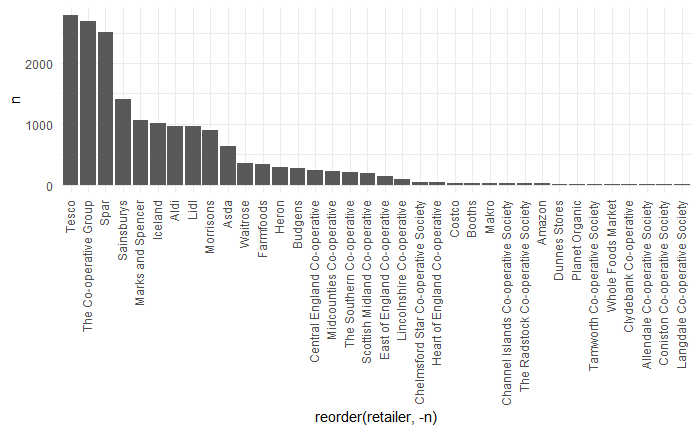

```r
# load starting data
all_stores <- read_xls('data/GEOLYTIX - UK RetailPoints/uk_glx_open_retail_points_v24_202206.xls')

# plot store count by retailer
retailer_count <- all_stores %>%
  group_by(retailer) %>%
  tally()

ggplot(retailer_count, aes(x = reorder(retailer, -n), y = n)) +
  geom_bar(stat = "identity") + theme_minimal() +
  theme(axis.text.x = element_text(angle = 90, hjust = 1, vjust = 0.3))
```

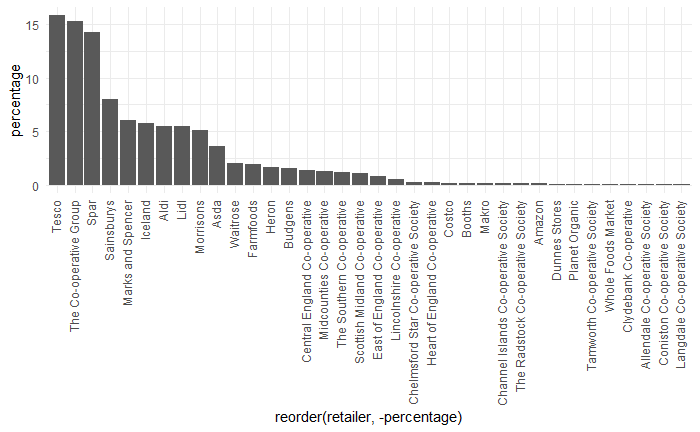

```r
# plot store count by cluster as %
retailer_count <- retailer_count %>%
  mutate(percentage = (n / sum(n))*100)

ggplot(retailer_count, aes(x = reorder(retailer, -percentage), y = percentage)) +
  geom_bar(stat = "identity") + theme_minimal() +
  theme(axis.text.x = element_text(angle = 90, hjust = 1, vjust = 0.3))
```

```r
# create list of largest stores
majors <- c("Aldi", "Asda", "Lidl", "Marks and Spencer", "Morrisons",
            "Sainsburys", "Tesco", "The Co-operative Group", "Waitrose")

# compute % of stores captured by major chains
print(retailer_count %>% filter(retailer %in% majors) %>% pull(percentage) %>% sum)
```

```
[1] 66.97561
```

```r
# 66.975 %
# the major chains capture 2/3rds of the universe

# plot location of major chains
major_retailers <- all_stores %>% filter(`retailer` %in% majors) %>%
  select(id, retailer, postcode, lng = long_wgs, lat = lat_wgs, size_band)

pal <- colorFactor(
  palette = c(
    "cyan", "green", "purple", "black", "yellow", "orange", "blue", "turquoise", "red"
    ),
  domain = major_retailers$retailer)

p <- leaflet(major_retailers) %>% addTiles() %>%
  addCircles(~lng, ~lat,color = ~pal(retailer)) %>%
  overlayTitle("Major Retailer Store Locations") %>%
  addLegend(position = "bottomright", values = ~retailer, pal = pal); p
```

[interactive chart not shown]

### Purchase of Competitor

Assuming we are Tesco (as the largest supermarket) and are looking to acquire one of the other chains, we could need to set a series of conditions under which we would acquire a competitor. In this example, let’s imagine these are simply:

1. Acquire based on which chain offers the “best coverage”- where there is minimum overlap with existing Tesco locations. i.e. find the competitor where least % of stores within a certain radius of Tesco stores
2. Of the stores with minimal overlap in coverage, which have a profile of store locations that best matches Tesco’s business strategy

```r
# we will set a cut-off of 500m each other - based on Haversine distance
major_retailers <- major_retailers %>%
  rowwise %>%
  mutate(coordinates = list(c(lng, lat))) %>%
  ungroup

# isolate the tesco locations
tesco_loc <- major_retailers %>%
  filter(retailer == "Tesco")

# obtain list of all other target brands
targets <- majors[majors != 'Tesco']

# iterate and compute % of each brand within 500m
for (brand in targets){

  target_loc <- major_retailers %>%
    filter(retailer == brand)

  close_stores <- calcCloseStore(tesco_loc, target_loc)

  print(brand)
  print((close_stores/nrow(target_loc))*100)
}
```

```
[1] "Aldi"
[1] 26.34298
[1] "Asda"
[1] 14.28571
[1] "Lidl"
[1] 29.41788
[1] "Marks and Spencer"
[1] 33.98876
[1] "Morrisons"
[1] 12.31964
[1] "Sainsburys"
[1] 33.30966
[1] "The Co-operative Group"
[1] 15.45048
[1] "Waitrose"
[1] 35.18006
```

```r
# ------results
# "Aldi"
# 26.34298
# "Asda"
# 14.28571
# "Lidl"
# 29.41788
# "Marks and Spencer"
# 33.98876
# "Morrisons"
# 12.31964
# "Sainsburys"
# 33.30966
# "The Co-operative Group"
# 15.45048
# "Waitrose"
# 35.18006
```

From the above results we see that Morrisons and Asda have the lowest %. We can now explore the profile of their respective store portfolios (to see the number of stores these brands offer by size)

```r
print(retailer_count %>% filter(retailer %in% c('Asda', 'Morrisons', 'The Co-operative Group')))
```

| retailer | n | percentage |
| --- | --- | --- |
| Asda | 637 | 3.621994 |
| Morrisons | 901 | 5.123102 |
| The Co-operative Group | 2686 | 15.272645 |

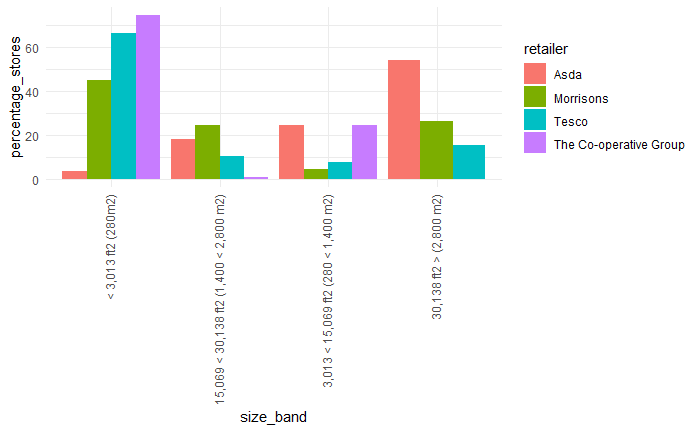

```r
# Asda        637
# Morrisons   901
# Coop        2686

# as well as the array of store sizes - and how this compares to Tesco
store_size_counts <- all_stores %>%
  filter(retailer %in% c('Tesco', 'Asda', 'Morrisons', 'The Co-operative Group')) %>%
  group_by(retailer, size_band) %>%
  tally() %>%
  group_by(retailer) %>%
  mutate(percentage_stores = (n / sum(n))*100)


ggplot(store_size_counts, aes(x = size_band, y = percentage_stores, fill=retailer)) +
  geom_col(position = "dodge") +
  theme_minimal() +
  theme(axis.text.x = element_text(angle = 90, hjust = 1, vjust = 0.3))
```

From glancing at the charts, it is fairly obvious on first inspection that’s Morrisons portfolio profile is more similar to Tesco than Asda, but let’s prove it statistically.

For this, we can leverage the chi-squared test. The chi-squared is used to evaluate whether there is significant association between the categories of two categorical variables. In theory it is designed to assess whether the two variables are independent of one another.

However, in our case we can view the different supermarket brands as our variables, and we could look for the brands to have low levels of independence compared to the Tesco distribution - as lower independence is equal to higher similarity in our case

```r
# convert to the correct structure
size_counts_wide <- store_size_counts %>%
  select(-n) %>%
  pivot_wider(names_from = retailer, values_from = percentage_stores) %>%
  replace(is.na(.), 0)

target_brands <- store_size_counts %>%
  select(retailer) %>%
  unique()

target_brands <- target_brands[target_brands != 'Tesco']

for (brand in target_brands){

  comparisons <- size_counts_wide %>%
    select(Tesco, brand)

  chisq <- chisq.test(comparisons)

  print(brand)
  print(chisq)
}
```

```
Note: Using an external vector in selections is ambiguous.
i Use `all_of(brand)` instead of `brand` to silence this message.
i See <https://tidyselect.r-lib.org/reference/faq-external-vector.html>.
[1] "Asda"

    Pearson's Chi-squared test

data:  comparisons
X-squared = 88.809, df = 3, p-value < 2.2e-16

[1] "Morrisons"

    Pearson's Chi-squared test

data:  comparisons
X-squared = 13.187, df = 3, p-value = 0.004249

[1] "The Co-operative Group"

    Pearson's Chi-squared test

data:  comparisons
X-squared = 33.52, df = 3, p-value = 2.501e-07
```

From the above we want to keep in mind the null hypothesis - which is to say that as p-value tends towards 0, the interdependence between the two distributions (i.e. similarity in behaviour) becomes less. Theoretically if p>=0.05 then the variables are not interdependent.

In our case (whil not >= 0.05) we see that the p-value for Morrisons is orders of magnitude greater than for the other brands, meaning it has the most similar profile - as expected.

In fact, Asda has a distinctly different business model, with far greater focus (with >50% of their stores) on large superstores (over 2800m2). Meanwhile, the Co-operative operates a set of primarily small stores, with zero superstores in the group.

Given Morrisons has one of the lower % of overlap, and the most similar profile, we elect to “acquire” it

```r
# create a combined dataset
combined_stores <- major_retailers %>%
  filter(retailer %in% c('Tesco', 'Morrisons'))

# now we have pretty good coverage across the UK
p <- leaflet(combined_stores) %>% addTiles() %>%
  addCircles(~lng, ~lat,color = 'blue', radius = 500, opacity = .5) %>%
  overlayTitle("Tesco Store Locations"); p
```

[interactive chart not shown]

```r
# save down combined dataset
write_rds(combined_stores, "data/combined_store.rds")
```

### Identifying Which Stores to Close

Now we have a group of store locations, next we can optimise the portfolio we will do this by opting to close stores in the same location and then defining some logic to prioritise which stores to keep stores

```r
# load checkpoint dataset
combined_stores <- read_rds("data/combined_store.rds")

# split by brand
tesco_stores <- combined_stores %>%
  filter(retailer == 'Tesco')

morrisons_stores <- combined_stores %>%
  filter(retailer == 'Morrisons')


# convert both tables to sf standard
tesco_stores_sf <- st_as_sf(tesco_stores, coords=c('lng', 'lat'), crs="epsg:4326")
morrisons_stores_sf <- st_as_sf(morrisons_stores, coords=c('lng', 'lat'), crs="epsg:4326")

# compute distance matrix
dist_sf = st_distance(tesco_stores_sf, morrisons_stores_sf)

# note: each row represents a Tesco location and columns their distance to a Morrisons store (in meters)
M <- as.matrix(dist_sf)
M <- unclass(M)

#create binary matrix to show where Tesco store (row) within 500m of Morrisons (column)
M[] <- ifelse(M<500,1,0)

# convert to dataframe and add column to indicate Tesco index number
dist_sf <- data.frame(M)

dist_sf <- rownames_to_column(dist_sf) %>%
  rename(tesco_index = rowname)

# convert from wide-form to long-form
close_store_df <- dist_sf %>%
  gather(key = morrisons_index, value = flag, -c(tesco_index)) %>%
  filter(flag == 1)

# clean up the morrions index column - removing the "X" from the naming convention
close_store_df <- close_store_df %>%
  rowwise() %>%
  mutate(morrisons_index = str_remove(morrisons_index, "X")) %>%
  ungroup

# check if we have any duplicates (i.e. one store close to two others)
nrow(close_store_df)
```

```
[1] 121
```

```r
# 121
n_distinct(close_store_df$tesco_index)
```

```
[1] 117
```

```r
# 117
n_distinct(close_store_df$morrisons_index)
```

```
[1] 111
```

```r
# 111

# join back to the Tesco master to indicate Morrisons locations
tesco_stores_df <- rownames_to_column(tesco_stores) %>%
  rename(tesco_index = rowname) %>%
  inner_join(close_store_df, by='tesco_index')

# join on the relevant Morrisons store data
morrisons_stores_df <- rownames_to_column(morrisons_stores) %>%
  rename(morrisons_index = rowname)

store_pairs <- tesco_stores_df %>%
  left_join(morrisons_stores_df, by='morrisons_index')
```

Now we have found all the store pairs (i.e. those that are within 500m of each other) from across the Tesco vs Morrison’s portfolio. The next stage would be to decide the logic on which to keep stores.

In our case (and for ease of progressing with the rest of the project notebook), we will assume that we will simply remove the Morrison’s store, and keep the existing Tesco stores.

However, in practice you may wish to look at demographic (specifically household income, or population density) data by postcode, and make some assumptions around whether you want higher price goods (usually in smaller stores) in areas of higher density or income.

```r
remove_ids <- store_pairs$id.y

combined_cut <- combined_stores %>%
  filter(!id %in% remove_ids)

nremove = nrow(combined_stores) - nrow(combined_cut)
print(paste0('number of stores removed: ', nremove))
```

```
[1] "number of stores removed: 111"
```

```r
write_rds(combined_cut, "data/combined_cut.rds")
```